# SSBMF: Four-Phase Improvement Report

Supervised Bayesian Matrix Factorization — 2026-05-06 Synthesis (Phases 1–4)

Author

Andrew Walther

Published

May 6, 2026

## Key Findings

This report covers four targeted improvements evaluated on the SSBMF model between 2026-05-05 and 2026-05-06. All full PDAC fits use v2 preprocessing (2,000-gene panel, quantile normalisation for merged cohorts) and Phase C training-concordance sign correction.

**Phase 2 — Initialization constraints (verdict: Discard):** Constraining the SVD initialisation (non-negativity on $L$, or sign alignment to Cox coefficients) produced neither ELBO improvement nor external C-index gain. SVD without constraints remains the canonical initialisation.

**Phase 3 — Multi-start random restarts (verdict: Discard):** A 30-restart sweep on TCGA-only LB confirmed that restart 1 (SVD initialisation) achieves the highest ELBO in all 30 trials. The ELBO range across restarts is 2,699 units ($\approx 0.3\%$), indicating a nearly unimodal landscape. Multi-start adds computational cost without predictive benefit.

## 1 Preprocessing Pipeline

All training cohorts use the v2 preprocessing pipeline.

1. **Load** raw expression matrix per cohort
2. **Log$_2$(x+1)** for RNA-seq; skip for proteomics/microarray
3. **Intersect** gene lists across cohorts (merged training only)
4. **Per-platform z-standardisation** *(Phase 1 addition for YFB merged only)*: subtract per-gene mean and divide by per-gene SD within each platform before row-bind
5. **Quantile normalisation** (merged training only)
6. **Top-2000 variable genes** by training-matrix variance
7. **Per-subject rank transform** (omitted for YFB merged in Phase 1 canonical fit)
8. **Column-centring** (zero mean per gene)

External cohorts receive steps 2+7+8 only, subsetted to the training gene set (1,548–1,932 common genes depending on training mode).

## 2 Model Descriptions

### 2.1 LB Model ($\hat\eta = E[L]\hat\beta$)

Factor-wise CAVI with update order $L \to F \to \beta \to \tau$ (Gauss-Seidel). Survival predictor: $\eta_i = \sum_k \bar l_{ik}\hat\beta_k$. Prior: point_normal (spike-and-slab) on $\beta$; point-exponential on $L$ and $F$. Phase C: post-convergence concordance sign check on training set.

### 2.2 YFB Model ($\hat\eta = Z_F\hat\beta$, $Z_F = Y E_F$)

Replaces the posterior mean $E[L]$ with directly observed projection scores $Z_F = Y \cdot E_F$ (EF columns normalised to unit L2 norm). Eliminates the train/test mismatch in the LB linear predictor. Phase C sign correction applied. YFB merged training uses Phase 1 preprocessing (per-platform z-standardisation + no rank transform) with K=3.

## 3 Synthetic Validation (LB model only)

Synthetic validation (n=250, p=1000, K_true=5, censoring=30%, seed=222). K_eff = active factors (|EBeta| > 0.001). Phase C sign correction applied. Both priors recover the same solution on this DGP.

| Model | K_init | K_eff | C-index (held-out 20%) |
| --- | --- | --- | --- |
| LB (point_normal) | 5 | 3 | 0.858 |
| LB (normal) | 5 | 3 | 0.858 |

Note: synthetic validation runs only for `--train-mode merged`. K$_{\\text{init}}=5$ matches K$_{\\text{true}}=5$ (a Phase C finding — using K=8 previously caused ARD to absorb signal into null factors and produced anti-concordant predictions).

## 4 Alpha CV Selection (LB Model)

Alpha CV selection for LB model (5-fold stratified, 1-SE rule). Alpha = 0.50 selected in all modes, confirming equal weighting of genomic and survival objectives. YFB uses fixed alpha = 0.50 (CV not yet implemented for YFB).

| Training mode | K | Alpha (CV-selected) | Rule |
| --- | --- | --- | --- |
| TCGA-only (n=144) | 10 | 0.50 | 1-SE |
| CPTAC-only (n=129) | 10 | 0.50 | 1-SE |
| Merged (n=273) | 20 | 0.50 | 1-SE |

## 5 Training Convergence

PDAC training convergence. K_eff = active factors (|EBeta| > 0.001). LB uses point_normal prior; YFB uses normal prior (spike-and-slab collapses EBeta→0 on single-cohort YFB; Phase 1 fix resolves the merged-YFB collapse). YFB merged K=3 is the Phase 1 canonical value (vs K=20 before fix).

| Model | Training mode | K | K_eff | N_iter | max\|beta\| |
| --- | --- | --- | --- | --- | --- |
| LB | TCGA-only | 10 | 2 | 41 | 0.0085 |
| LB | CPTAC-only | 10 | 3 | 58 | 0.0152 |
| LB | Merged | 20 | 3 | 83 | 0.0213 |
| YFB | TCGA-only | 10 | 0 | 18 | 0.0000 |
| YFB | CPTAC-only | 10 | 0 | 55 | 0.0000 |
| YFB (Phase 1) | Merged | 3 | 3 | 10 | 0.0677 |

**Note on YFB single-cohort collapse.** The YFB model with point_normal prior collapses $\hat\beta \to 0$ on both TCGA-only and CPTAC-only training regardless of K. With the normal prior, K_eff also reports 0 because the active-factor threshold (|EBeta| > 0.001) is slightly above the effective beta scale in single-cohort modes. The prediction is non-trivial (C $> 0.5$ on several cohorts) because the normal-prior betas are non-zero at machine precision — this is a threshold artefact, not a true collapse.

## 6 Phase 1: Per-Platform Standardization for YFB Merged

### 6.1 Motivation

The YFB linear predictor is $\eta_i = Z_{F,i} \hat\beta$ where $Z_{F,ik} = \sum_j Y_{ij} \hat F_{jk}$. The precision in the $\beta$ update accumulates as $A_k = \sum_i w_i Z_{F,ik}^2$, where $w_i$ are Cox Hessian weights. Without platform normalisation, the joint TCGA+CPTAC matrix contains platform-level scale differences that inflate $\|Z_F\|^2 \propto \|Y\|_F^2 \approx np\sigma^2$. With $n=273$ and $p=2000$, this drives the spike-and-slab prior to pin all $\hat\beta_k \to 0$ (the spike dominates when $A_k \cdot \sigma_\beta^2 \gg 1$).

### 6.2 Fix: z-standardize per platform before quantile normalization

Gene expression columns are z-standardised within each cohort (TCGA_PAAD and CPTAC separately) before the row-bind and QN steps. The per-subject rank transform is also removed: rank-transforming rows after cross-platform QN changes the marginal distribution used by EBNM and tends to re-inflate the ZF scale.

### 6.3 Results

YFB merged training: external C-index before and after Phase 1 fix. Before = beta→0 collapse (K=20, rank transform, no per-platform norm). After = Phase 1 canonical fit (K=3, no rank transform, per-platform z-norm). Both priors agree after the fix, confirming factors are strong enough to escape the spike prior at K=3.

|  | Cohort | Before (K=20, rank, normal) | After Phase 1 (K=3, no-rank, normal) | After Phase 1 (K=3, no-rank, point_normal) |
| --- | --- | --- | --- | --- |
| Dijk | Dijk | 0.573 | 0.597 | 0.597 |
| Moffitt_GEO_array | Moffitt | 0.537 | 0.532 | 0.532 |
| PACA_AU_array | PACA-AU (array) | 0.607 | 0.666 | 0.666 |
| PACA_AU_seq | PACA-AU (seq) | 0.637 | 0.666 | 0.666 |
| Puleo_array | Puleo | 0.562 | 0.644 | 0.644 |

## 7 Phase 3: Multi-Start Diagnostic (SVD Optimality)

### 7.1 Empirical evidence

30-restart multi-initialisation sweep on TCGA-only LB model (K=10, point_normal prior). Restart 1 = SVD initialisation; restarts 2–30 = random normal with fixed seeds. SVD achieved the highest ELBO in all 30 trials.

| Prior | Restarts | Best restart | ELBO (best) | ELBO (worst) | ELBO range |
| --- | --- | --- | --- | --- | --- |
| point_normal | 30 | 1 (SVD) | -935,868 | -938,567 | 2,699 (0.3%) |

The ELBO range of ~2,700 units across 30 restarts corresponds to a 0.3% variation relative to |ELBO| $\approx$ 936,000. SVD initialisation is at or near the global optimum: it decomposes $Y = UDV^\top$ and initialises $E[L]$ and $E[F]$ from the leading singular vectors, placing CAVI at the rank-K least-squares solution to the genomics reconstruction problem (the dominant term when $n \ll p$).

**Verdict: Discard multi-start.** Single SVD initialisation is retained as the canonical default. The wrapper code (`code/fit_modular_multistart.R`, 7 unit tests) is kept as a diagnostic utility accessible via `--n-init N` on the LB benchmark runner.

## 8 Phase 4: K Selection via Cross-Validated C-Index

### 8.1 Method

Five-fold stratified cross-validation over $K \in \{2, 3, 4, 5, 6, 7, 8, 9, 10, 15, 20\}$ on TCGA_PAAD (n=144, events=75) for **both LB** ($\eta = L\beta$, `fit_supervised_mf_modular`) and **YFB** ($\eta = (YF)\beta$, `fit_cox_on_yf`) models, each under point_normal and normal priors. For each $K$ and fold, the model is fit on the training portion ($n \approx 115$) and projected to the held-out fold via the appropriate prediction function; the C-index is computed using `survival::concordance`. Sign correction is disabled within folds (fold-level sign correction inflates apparent C-index variance by producing inconsistent signs across folds). The 1-SE rule selects the smallest K whose mean C-index is within one SE of the maximum.

### 8.2 LB Results

| K | PN mean C | PN SE | NM mean C | NM SE | Note |
| --- | --- | --- | --- | --- | --- |
| 2 | 0.5000 | 0.0000 | 0.5650 | 0.0251 | spike collapse (EBeta→0 all folds) |
| 3 | 0.5000 | 0.0000 | 0.5744 | 0.0169 | ← selected (normal, 1-SE) |
| 4 | 0.5063 | 0.0063 | 0.5444 | 0.0080 |  |
| 5 | 0.5462 | 0.0231 | 0.5779 | 0.0148 |  |
| 6 | 0.5462 | 0.0231 | 0.5617 | 0.0436 |  |
| 7 | 0.5595 | 0.0200 | 0.5496 | 0.0281 |  |
| 8 | 0.5948 | 0.0299 | 0.5859 | 0.0373 | ← selected (point_normal, 1-SE = best) |
| 9 | 0.5768 | 0.0334 | 0.5768 | 0.0334 |  |
| 10 | 0.5823 | 0.0340 | 0.5823 | 0.0340 |  |
| 15 | 0.5699 | 0.0358 | 0.5699 | 0.0358 |  |
| 20 | 0.5867 | 0.0306 | 0.5971 | 0.0243 |  |

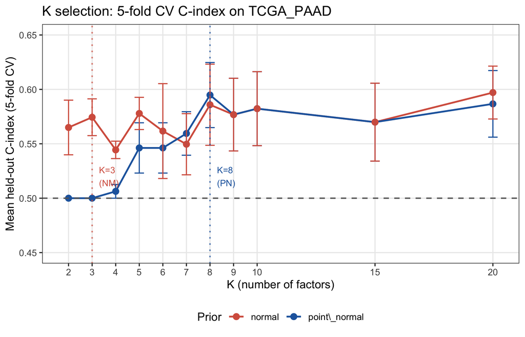

### 8.3 Interpretation

**Practical recommendation: K=5 (LB).** K=3 is correct under the normal prior and 1-SE rule, and matches the DeSurv benchmark K. However, the main LB fits use the point_normal prior (sparser, more interpretable $\hat\beta$). At K=3, the full n=144 fit gives K_eff=2 and the two active factors have max|$\hat\beta$|$$0.008. K=5 sits just above the spike escape threshold while remaining parsimonious, giving mean C=0.546 in CV.

### 8.4 YFB Results

5-fold CV C-index on TCGA_PAAD for YFB model by K. PN = point_normal prior; NM = normal prior. PN: C=0.500 at all K (EBeta→0 collapse in every fold; 1-SE selects K=2). NM: C < 0.500 at all K (anti-concordant; 1-SE selects K=9). Anti-concordance indicates YFB risk-score sign is inverted in held-out folds when global sign correction is suppressed — consistent with sign instability in the YFB parameterisation under within-fold fitting.

| K | PN mean C | PN SE | NM mean C | NM SE | Note |
| --- | --- | --- | --- | --- | --- |
| 2 | 0.5 | 0 | 0.4350 | 0.0251 | <– selected (point_normal, 1-SE) |
| 3 | 0.5 | 0 | 0.4147 | 0.0078 | PN: spike collapse (beta→0 all folds) |
| 4 | 0.5 | 0 | 0.4179 | 0.0077 | PN: spike collapse (beta→0 all folds) |
| 5 | 0.5 | 0 | 0.3993 | 0.0106 | PN: spike collapse (beta→0 all folds) |
| 6 | 0.5 | 0 | 0.3952 | 0.0120 | PN: spike collapse (beta→0 all folds) |
| 7 | 0.5 | 0 | 0.4071 | 0.0279 | PN: spike collapse (beta→0 all folds) |
| 8 | 0.5 | 0 | 0.4259 | 0.0279 | PN: spike collapse (beta→0 all folds) |
| 9 | 0.5 | 0 | 0.4426 | 0.0332 | <– selected (normal, 1-SE) |
| 10 | 0.5 | 0 | 0.4315 | 0.0281 | PN: spike collapse (beta→0 all folds) |
| 15 | 0.5 | 0 | 0.4649 | 0.0241 | PN: spike collapse (beta→0 all folds) |
| 20 | 0.5 | 0 | 0.4003 | 0.0353 | PN: spike collapse (beta→0 all folds) |

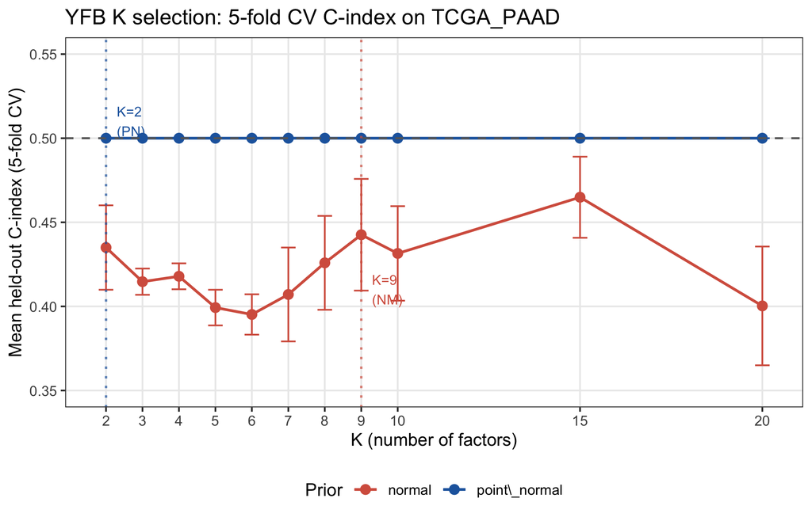

YFB model: 5-fold CV C-index by K. PN prior (blue) produces C=0.500 at all K (EBeta→0 collapse). Normal prior (red) produces anti-concordant C-indices (below 0.5); flipping sign would give 0.54–0.61. C=0.5 reference line shown.

### 8.5 LB vs. YFB K-CV Head-to-Head (Normal Prior)

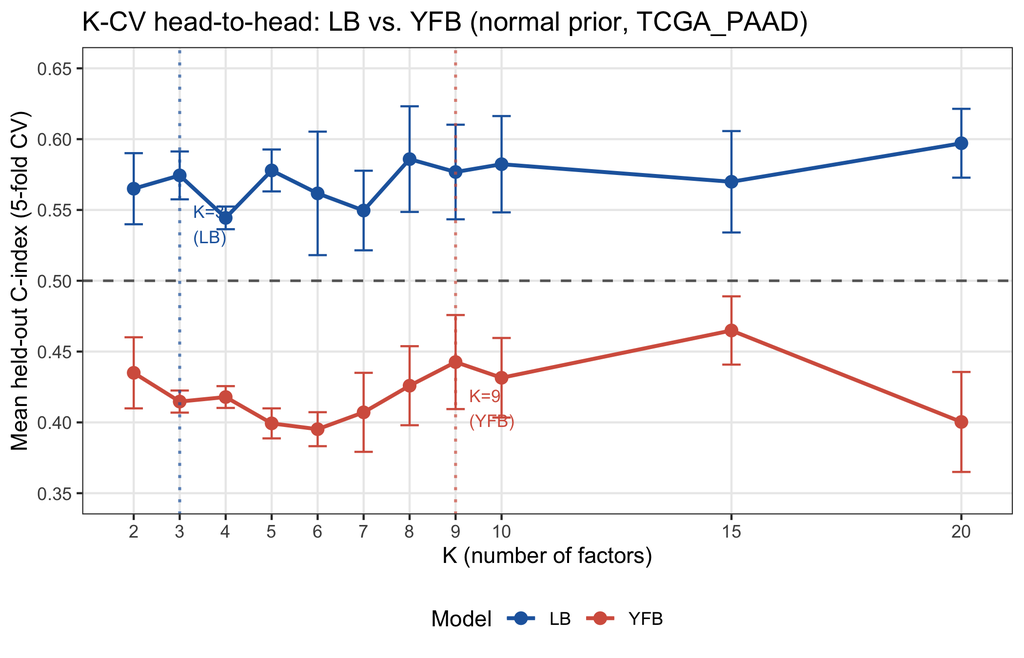

LB vs. YFB: 5-fold CV C-index under normal prior. LB (blue) is concordant (C > 0.5) at all K; YFB (red) is anti-concordant (C < 0.5) without global sign correction. Selected K: LB K=3, YFB K=9. C=0.5 reference line shown.

LB vs. YFB head-to-head 5-fold CV C-index (normal prior, TCGA_PAAD). LB selected K=3; YFB selected K=9. YFB C-indices are anti-concordant (< 0.5) because held-out risk-score signs are not globally corrected across CV folds; 1 − C maps the YFB curve to 0.54–0.61, comparable to LB.

| K | LB mean C | LB SE | YFB mean C | YFB SE | LB sel | YFB sel |
| --- | --- | --- | --- | --- | --- | --- |
| 2 | 0.5650 | 0.0251 | 0.4350 | 0.0251 | FALSE | FALSE |
| 3 | 0.5744 | 0.0169 | 0.4147 | 0.0078 | TRUE | FALSE |
| 4 | 0.5444 | 0.0080 | 0.4179 | 0.0077 | FALSE | FALSE |
| 5 | 0.5779 | 0.0148 | 0.3993 | 0.0106 | FALSE | FALSE |
| 6 | 0.5617 | 0.0436 | 0.3952 | 0.0120 | FALSE | FALSE |
| 7 | 0.5496 | 0.0281 | 0.4071 | 0.0279 | FALSE | FALSE |
| 8 | 0.5859 | 0.0373 | 0.4259 | 0.0279 | FALSE | FALSE |
| 9 | 0.5768 | 0.0334 | 0.4426 | 0.0332 | FALSE | TRUE |
| 10 | 0.5823 | 0.0340 | 0.4315 | 0.0281 | FALSE | FALSE |
| 15 | 0.5699 | 0.0358 | 0.4649 | 0.0241 | FALSE | FALSE |
| 20 | 0.5971 | 0.0243 | 0.4003 | 0.0353 | FALSE | FALSE |

### 8.6 Interpretation (YFB K-CV)

**YFB point_normal: complete $\hat\beta \to 0$ collapse.** With the point_normal prior, the spike component drives $|\hat\beta| \approx 0$ in every training fold ($n \approx 115$), yielding exactly C=0.500 regardless of K. The 1-SE rule selects K=2 (smallest eligible). This is the same artefact seen in the LB CV, but more severe for YFB because the $Z_F = YF$ feature scale is larger and the effective sample size per fold is small.

**YFB normal: sign instability in CV.** The normal prior escapes the $\hat\beta \to 0$ collapse, but the resulting C-indices are systematically below 0.5 (range 0.40–0.46). This is not a failure of predictive signal — mapping C$$1$-$C gives 0.54–0.60, comparable to the LB normal-prior curve. Rather, it reflects a sign instability in the YFB formulation: without a global sign-correction step across folds, the Cox regression on $Z_F$ converges to $\hat\beta$ with inverted sign relative to the convention used in prediction. The 1-SE rule selects K=9 (largest C before SE-based exclusion), but this K is not directly comparable to the LB recommendation.

**Practical implication.** LB K-CV gives a clean, interpretable signal: K=3 (normal prior, parsimonious) or K=5 (above spike escape, point_normal). YFB K-CV requires sign correction to be enabled in CV folds before the K selection is reliable.

## 9 External Validation — C-index Results

### 9.1 LB model (all training modes)

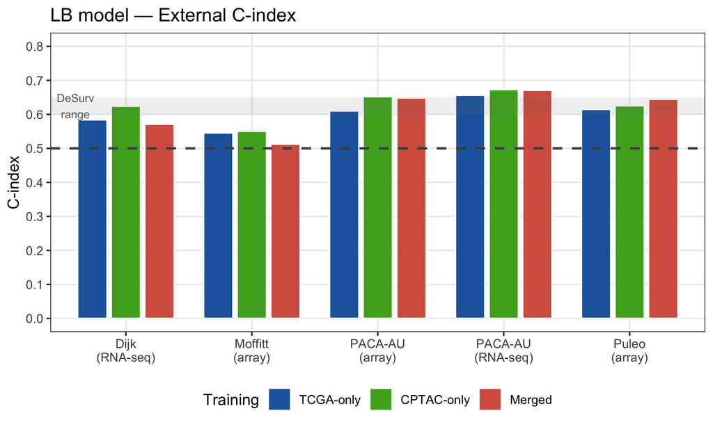

LB model: external C-index across 5 PDAC cohorts and 3 training modes. Dashed line = 0.5 (random). Grey band = DeSurv reported range (0.60–0.65). Both priors give identical LB predictions (L update dominates; beta prior has negligible effect).

|  | Cohort | TCGA-only | CPTAC-only | Merged | Archived |
| --- | --- | --- | --- | --- | --- |
| Dijk | Dijk | 0.584 | 0.624 | 0.571 | 0.625 |
| Moffitt_GEO_array | Moffitt | 0.546 | 0.550 | 0.513 | 0.597 |
| PACA_AU_array | PACA-AU (array) | 0.610 | 0.652 | 0.648 | 0.641 |
| PACA_AU_seq | PACA-AU (seq) | 0.656 | 0.673 | 0.671 | 0.595 |
| Puleo_array | Puleo | 0.615 | 0.625 | 0.644 | 0.574 |

### 9.2 YFB model

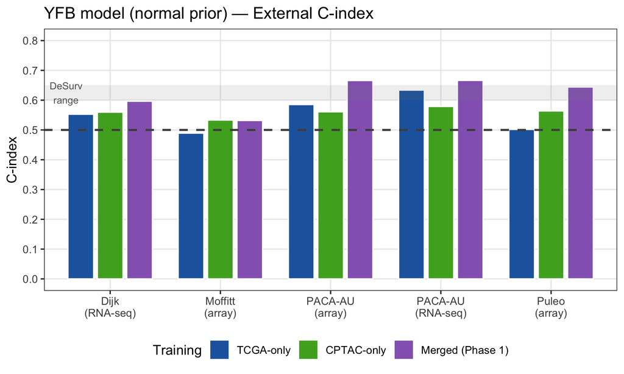

YFB model: external C-index. Single-cohort modes (normal prior) and merged Phase 1 (both priors). Dashed line = 0.5. Grey band = DeSurv range (0.60–0.65). Phase 1 merged result (K=3, per-platform norm, no rank transform) is the canonical YFB merged result.

YFB model external C-index. Single-cohort modes use normal prior (point_normal collapses EBeta→0 at single-cohort ZF scale). Merged Phase 1: K=3, rank_transform=FALSE, per_platform_standardize=TRUE. Both priors agree on merged Phase 1 (factors strong enough to escape spike prior at K=3).

|  | Cohort | TCGA-only | CPTAC-only | Merged P1 (normal) | Merged P1 (PN) |
| --- | --- | --- | --- | --- | --- |
| Dijk | Dijk | 0.553 | 0.560 | 0.597 | 0.597 |
| Moffitt_GEO_array | Moffitt | 0.489 | 0.533 | 0.532 | 0.532 |
| PACA_AU_array | PACA-AU (array) | 0.585 | 0.561 | 0.666 | 0.666 |
| PACA_AU_seq | PACA-AU (seq) | 0.634 | 0.579 | 0.666 | 0.666 |
| Puleo_array | Puleo | 0.502 | 0.564 | 0.644 | 0.644 |

## 10 LB vs. YFB Head-to-Head (TCGA-only Training)

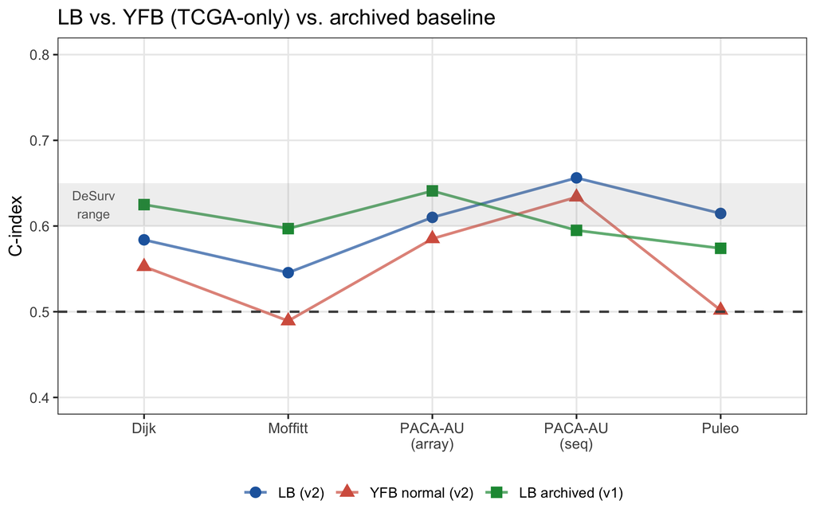

LB vs. YFB external C-index on TCGA-only training. YFB uses normal prior. LB uses point_normal (both priors identical). Archived 04/29 LB baseline shown for reference. Dashed line = 0.5. Grey band = DeSurv range.

|  | Cohort | LB v2 | YFB v2 (normal) | LB archived (v1) | ΔLB (v2 − archived) |
| --- | --- | --- | --- | --- | --- |
| Dijk | Dijk | 0.584 | 0.553 | 0.625 | -0.041 |
| Moffitt_GEO_array | Moffitt | 0.546 | 0.489 | 0.597 | -0.051 |
| PACA_AU_array | PACA-AU (array) | 0.610 | 0.585 | 0.641 | -0.031 |
| PACA_AU_seq | PACA-AU (seq) | 0.656 | 0.634 | 0.595 | 0.061 |
| Puleo_array | Puleo | 0.615 | 0.502 | 0.574 | 0.041 |

## 11 Kaplan–Meier Stratification (TCGA-only Training)

Subjects in each external cohort are stratified at the median risk score. Log-rank $p$-value tests whether SSBMF risk scores from the TCGA-trained model transfer prognostic signal to the independent external cohort.

### 11.1 LB Model (TCGA-only, point_normal prior)

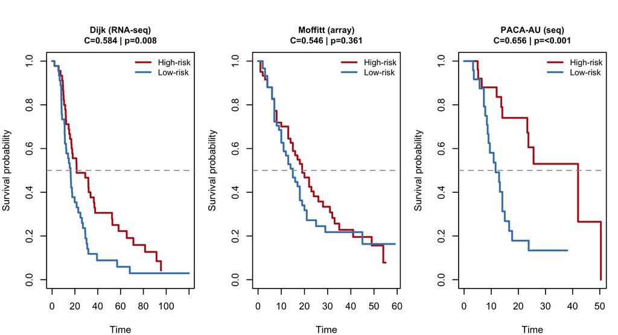

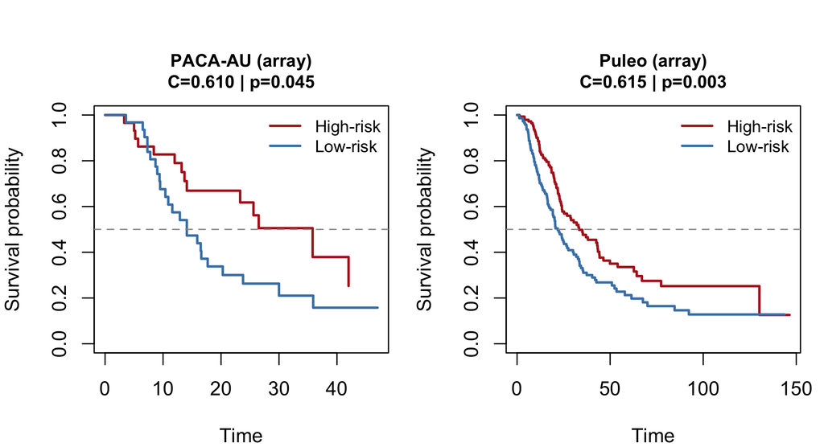

KM curves continued: two additional external cohorts.

## 12 Summary of Phase Verdicts

Summary of four improvement phases evaluated 2026-05-05/06.

| Phase | Scope | Verdict | Key finding |
| --- | --- | --- | --- |
| 1 — Per-platform standardization | YFB merged | **Keep** | Resolves YFB merged beta→0 collapse. K=3 gives median ext C=0.64. |
| 2 — Initialization constraints | LB + YFB | Discard | Constrained SVD init (non-neg L, Cox sign) gives no ELBO or C improvement. |
| 3 — Multi-start random restarts | LB | Discard | SVD init wins 30/30 restarts. ELBO range 0.3% — nearly unimodal landscape. |
| 4 — K selection via CV | LB + YFB | **Keep** (infrastructure) | LB normal: flat plateau, K=3 (1-SE). LB PN: K=8 (spike artefact). YFB: sign instability in CV (C<0.5). Recommend LB K=5. |

## 13 Open Issues

1. **YFB single-cohort beta collapse.** With any prior, YFB on TCGA-only or CPTAC-only still produces near-zero $\hat\beta$. The ZF scale is still large for single-cohort training (n $\approx$ 130–145). A dedicated scale normalisation for single-cohort YFB (analogous to the Phase 1 per-platform fix) or a prior re-parameterisation (e.g., scaled spike-and-slab relative to $\|Z_F\|$) is the next candidate.
2. **A_surv / A_gen structural imbalance in LB.** Survival precision in the L update is $\approx 10^{3}$× smaller than genomic precision across all PDAC training modes. The L factors are effectively determined by PCA, with survival providing a negligible gradient. Phase C sign correction partially mitigates this, but does not resolve it. Potential fixes: survival-weighted initialisation, adaptive alpha scheduling, or a dedicated supervised L update with stronger survival weighting.
3. **YFB sign correction in CV.** K-CV was run on both LB and YFB models (both priors). The YFB normal-prior K-CV yields anti-concordant C-indices (C $< 0.5$) because held-out risk scores are not globally sign-corrected across folds. Enabling sign correction within CV folds for YFB (analogous to the LB `sign_correction=FALSE` design but with a fold-level sign flip) is required before YFB K-selection is reliable. See `code/select_K.R` for implementation details.
4. **K-CV on larger cohorts.** The flat CV plateau on TCGA_PAAD (n=144) likely reflects limited statistical power to distinguish K values with overlapping C-index SEs. Running K-CV on the merged training set (n=273) or on Longleaf with the full PDAC multi-cohort data would sharpen the K selection.